# CKME136 Capstone - Cleaning and Exploratory Analysis of Diabetes Readmission Data

Amy Howe

# Packages

Install and load required packages, if needed.

```r
if(!require('tidyverse')){install.packages('tidyverse')} # For factor collapsing
library(tidyverse)
if(!require('ggplot2')){install.packages('ggplot2')} # For visualizations
library(ggplot2)
if(!require('gridExtra')){install.packages('gridExtra')} # For visualizations
library(gridExtra)
if(!require('corrplot')){install.packages('corrplot')} # For visualizations
library(corrplot)
if(!require('Hmisc')){install.packages('Hmisc')} # For rcorr function
library(Hmisc)
if(!require('ggcorrplot')){install.packages('ggcorrplot')} # For correlation heatmap
library(ggcorrplot)
if(!require('dplyr')){install.packages('dplyr')} # For grouping
library(dplyr)
if(!require('mltools')){install.packages('mltools')} # To create dummy variables
library(mltools)
if(!require('data.table')){install.packages('data.table')} # To create dummy variables
library(data.table)
```

# Initial Data Cleaning

First import the raw data, and save it to the object db.raw

```r
db.raw <- read.csv('/Users/amyhowe/Desktop/diabetic_data.csv')
```

Let’s take a look at the structure of the dataset, and identify if there are any duplicated rows or “NA” values.

```r
str(db.raw) # There are 50 variables and 101766 observations
```

```
## 'data.frame':    101766 obs. of  50 variables:
##  $ encounter_id            : int  2278392 149190 64410 500364 16680 35754 55842 63768 12522 15738 ...
##  $ patient_nbr             : int  8222157 55629189 86047875 82442376 42519267 82637451 84259809 114882984 48330783 63555939 ...
##  $ race                    : Factor w/ 6 levels "?","AfricanAmerican",..: 4 4 2 4 4 4 4 4 4 4 ...
##  $ gender                  : Factor w/ 3 levels "Female","Male",..: 1 1 1 2 2 2 2 2 1 1 ...
##  $ age                     : Factor w/ 10 levels "[0-10)","[10-20)",..: 1 2 3 4 5 6 7 8 9 10 ...
##  $ weight                  : Factor w/ 10 levels "?","[0-25)","[100-125)",..: 1 1 1 1 1 1 1 1 1 1 ...
##  $ admission_type_id       : int  6 1 1 1 1 2 3 1 2 3 ...
##  $ discharge_disposition_id: int  25 1 1 1 1 1 1 1 1 3 ...
##  $ admission_source_id     : int  1 7 7 7 7 2 2 7 4 4 ...
##  $ time_in_hospital        : int  1 3 2 2 1 3 4 5 13 12 ...
##  $ payer_code              : Factor w/ 18 levels "?","BC","CH",..: 1 1 1 1 1 1 1 1 1 1 ...
##  $ medical_specialty       : Factor w/ 73 levels "?","AllergyandImmunology",..: 39 1 1 1 1 1 1 1 1 20 ...
##  $ num_lab_procedures      : int  41 59 11 44 51 31 70 73 68 33 ...
##  $ num_procedures          : int  0 0 5 1 0 6 1 0 2 3 ...
```

[output cut: 36 more lines]

```r
length(subset(duplicated(db.raw), duplicated(db.raw) == TRUE)) # The output is 0, indicating there are no fully duplicated rows
```

```
## [1] 0
```

```r
sum(is.na(db.raw)) # There are no "NA" values in entire dataset
```

```
## [1] 0
```

## Convert Attributes to Correct Data Types

Now we will convert attributes to the correct data types, and add in any missing level names.

```r
db.init <- db.raw # Put the dataset in a new object for initial analysis and cleaning
sapply(db.init[,c(3:6,11:12,23:50)], levels) # The levels of all factor attributes except for the diagnoses were checked here for overlap - none present
```

```
## $race
## [1] "?"               "AfricanAmerican" "Asian"           "Caucasian"
## [5] "Hispanic"        "Other"
##
## $gender
## [1] "Female"          "Male"            "Unknown/Invalid"
##
## $age
##  [1] "[0-10)"   "[10-20)"  "[20-30)"  "[30-40)"  "[40-50)"  "[50-60)"
##  [7] "[60-70)"  "[70-80)"  "[80-90)"  "[90-100)"
##
## $weight
##  [1] "?"         "[0-25)"    "[100-125)" "[125-150)" "[150-175)" "[175-200)"
##  [7] "[25-50)"   "[50-75)"   "[75-100)"  ">200"
##
## $payer_code
##  [1] "?"  "BC" "CH" "CM" "CP" "DM" "FR" "HM" "MC" "MD" "MP" "OG" "OT" "PO" "SI"
## [16] "SP" "UN" "WC"
##
## $medical_specialty
##  [1] "?"
##  [2] "AllergyandImmunology"
##  [3] "Anesthesiology"
##  [4] "Anesthesiology-Pediatric"
##  [5] "Cardiology"
##  [6] "Cardiology-Pediatric"
##  [7] "DCPTEAM"
##  [8] "Dentistry"
##  [9] "Dermatology"
## [10] "Emergency/Trauma"
## [11] "Endocrinology"
## [12] "Endocrinology-Metabolism"
## [13] "Family/GeneralPractice"
## [14] "Gastroenterology"
## [15] "Gynecology"
## [16] "Hematology"
## [17] "Hematology/Oncology"
## [18] "Hospitalist"
## [19] "InfectiousDiseases"
## [20] "InternalMedicine"
```

[output cut: 122 more lines]

```
##
## $metformin.rosiglitazone
## [1] "No"     "Steady"
##
## $metformin.pioglitazone
## [1] "No"     "Steady"
##
## $change
## [1] "Ch" "No"
##
## $diabetesMed
## [1] "No"  "Yes"
##
## $readmitted
## [1] "<30" ">30" "NO"
```

```r
db.init$weight <- factor(db.init$weight, levels = c("?", "[0-25)", "[25-50)", "[50-75)", "[75-100)", "[100-125)", "[125-150)", "[150-175)", "[175-200)", ">200")) # Reorder the factor levels for weight to represent true ordering

# Need to convert admission_type_id, discharge_disposition_id and admission_source_id each to a factor and add in level names (based on supplementary id_mapping document)

table(db.init$admission_type_id) # Confirmed that all levels (1-8) are present and each have cases
```

```
##
##     1     2     3     4     5     6     7     8
## 53990 18480 18869    10  4785  5291    21   320
```

```r
db.init$admission_type_id <- as.factor(db.init$admission_type_id)
levels(db.init$admission_type_id) <- c('Emergency', 'Urgent', 'Elective', 'Newborn', 'NotAvailable', 'NULL', 'TraumaCenter', 'NotMapped')

table(db.init$discharge_disposition_id) # Categories 21, 26, 29, and 30 are missing when compared to id_mapping doc; missing because 0 cases; will not add level names for them
```

```
##
##     1     2     3     4     5     6     7     8     9    10    11    12    13
## 60234  2128 13954   815  1184 12902   623   108    21     6  1642     3   399
##    14    15    16    17    18    19    20    22    23    24    25    27    28
##   372    63    11    14  3691     8     2  1993   412    48   989     5   139
```

```r
db.init$discharge_disposition_id <- as.factor(db.init$discharge_disposition_id)
levels(db.init$discharge_disposition_id) <- c('DcHome', 'DcAnotherSTHospital', 'DcSNF', 'DcICF', 'DcOtherTypeInpatient', 'DcHomeWithHomeService', 'LeftAMA', 'DcHomeWithIVCare', 'AdmittedInpatientThisHospital', 'NeonateDcOtherHospital', 'Expired', 'StillPatientOrOutpatient', 'HospiceHome', 'HospiceFacility', 'DcWithinSwingBed', 'RefOtherOutpatient', 'RefSameOutpatient', 'NULL', 'ExpiredHome', 'ExpiredFacility', 'DcRehab', 'DcLTCHospital', 'DcMedicaidNursingFacility', 'NotMapped', 'DcFederalHealthFacility','DcPsychiatric')

table(db.init$admission_source_id) # Categories 12, 15, 18, 19, 21, 23, 24, and 26 are missing when compared to id_mapping doc. Note: there is no category 16 in the id_mapping doc, nor is one present in the data
```

```
##
##     1     2     3     4     5     6     7     8     9    10    11    13    14
## 29565  1104   187  3187   855  2264 57494    16   125     8     2     1     2
##    17    20    22    25
##  6781   161    12     2
```

```r
db.init$admission_source_id <- as.factor(db.init$admission_source_id)
levels(db.init$admission_source_id) <- c('PhysRef', 'ClinicRef', 'HMORef', 'TransferFromHospital', 'TransferFromSNF', 'TransferFromOtherHealthFacility', 'ER', 'CourtOrLawEnf', 'NotAvailable', 'TransferFromCriticalAccessHospital', 'NormalDelivery', 'SickBaby', 'ExtramuralBirth', 'NULL', 'NotMapped', 'SepClaim', 'TransferFromAmbSurg')

# No need to check specifically for overlap in levels of diagnoses, as these are all ICD-9-CM codes. Just skimmed the levels to ensure the levels were either ICD codes or '?'
levels(db.init$diag_1)
```

```
##   [1] "?"      "10"     "11"     "110"    "112"    "114"    "115"    "117"
##   [9] "131"    "133"    "135"    "136"    "141"    "142"    "143"    "145"
##  [17] "146"    "147"    "148"    "149"    "150"    "151"    "152"    "153"
##  [25] "154"    "155"    "156"    "157"    "158"    "160"    "161"    "162"
##  [33] "163"    "164"    "170"    "171"    "172"    "173"    "174"    "175"
##  [41] "179"    "180"    "182"    "183"    "184"    "185"    "187"    "188"
##  [49] "189"    "191"    "192"    "193"    "194"    "195"    "196"    "197"
##  [57] "198"    "199"    "200"    "201"    "202"    "203"    "204"    "205"
##  [65] "207"    "208"    "210"    "211"    "212"    "214"    "215"    "216"
##  [73] "217"    "218"    "219"    "220"    "223"    "225"    "226"    "227"
##  [81] "228"    "229"    "23"     "230"    "233"    "235"    "236"    "237"
##  [89] "238"    "239"    "240"    "241"    "242"    "244"    "245"    "246"
##  [97] "250"    "250.01" "250.02" "250.03" "250.1"  "250.11" "250.12" "250.13"
## [105] "250.2"  "250.21" "250.22" "250.23" "250.3"  "250.31" "250.32" "250.33"
## [113] "250.4"  "250.41" "250.42" "250.43" "250.5"  "250.51" "250.52" "250.53"
```

[output cut: 75 more lines]

```r
levels(db.init$diag_2)
```

```
##   [1] "?"      "11"     "110"    "111"    "112"    "114"    "115"    "117"
##   [9] "123"    "130"    "131"    "135"    "136"    "137"    "138"    "140"
##  [17] "141"    "145"    "150"    "151"    "152"    "153"    "154"    "155"
##  [25] "156"    "157"    "162"    "163"    "164"    "171"    "172"    "173"
##  [33] "174"    "179"    "180"    "182"    "183"    "185"    "186"    "188"
##  [41] "189"    "191"    "192"    "193"    "195"    "196"    "197"    "198"
##  [49] "199"    "200"    "201"    "202"    "203"    "204"    "205"    "208"
##  [57] "211"    "212"    "214"    "215"    "217"    "218"    "220"    "223"
##  [65] "225"    "226"    "227"    "228"    "232"    "233"    "235"    "238"
##  [73] "239"    "240"    "241"    "242"    "244"    "245"    "246"    "250"
##  [81] "250.01" "250.02" "250.03" "250.1"  "250.11" "250.12" "250.13" "250.2"
##  [89] "250.21" "250.22" "250.23" "250.3"  "250.31" "250.32" "250.33" "250.4"
##  [97] "250.41" "250.42" "250.43" "250.5"  "250.51" "250.52" "250.53" "250.6"
## [105] "250.7"  "250.8"  "250.81" "250.82" "250.83" "250.9"  "250.91" "250.92"
## [113] "250.93" "251"    "252"    "253"    "255"    "256"    "258"    "259"
```

[output cut: 79 more lines]

```r
levels(db.init$diag_3)
```

```
##   [1] "?"      "11"     "110"    "111"    "112"    "115"    "117"    "122"
##   [9] "123"    "131"    "132"    "135"    "136"    "138"    "139"    "14"
##  [17] "141"    "146"    "148"    "150"    "151"    "152"    "153"    "154"
##  [25] "155"    "156"    "157"    "158"    "161"    "162"    "163"    "164"
##  [33] "17"     "170"    "171"    "172"    "173"    "174"    "175"    "179"
##  [41] "180"    "182"    "183"    "185"    "186"    "188"    "189"    "191"
##  [49] "192"    "193"    "195"    "196"    "197"    "198"    "199"    "200"
##  [57] "201"    "202"    "203"    "204"    "205"    "208"    "211"    "214"
##  [65] "215"    "216"    "217"    "218"    "220"    "223"    "225"    "226"
##  [73] "227"    "228"    "230"    "233"    "235"    "236"    "238"    "239"
##  [81] "240"    "241"    "242"    "243"    "244"    "245"    "246"    "250"
##  [89] "250.01" "250.02" "250.03" "250.1"  "250.11" "250.12" "250.13" "250.2"
##  [97] "250.21" "250.22" "250.23" "250.3"  "250.31" "250.4"  "250.41" "250.42"
## [105] "250.43" "250.5"  "250.51" "250.52" "250.53" "250.6"  "250.7"  "250.8"
## [113] "250.81" "250.82" "250.83" "250.9"  "250.91" "250.92" "250.93" "251"
```

[output cut: 84 more lines]

All remaining attributes are the correct data types.

## Remove Out of Scope Cases

If there are multiple encounters for the same patient, we want to remove any after the first one. This is because we want to ensure observations are independent, so that we may run statistical tests on them during analysis and not violate the assumption of independence. We are interested in the the first encounter of each patient, as we are focused on early identification of the risks of readmission.

Additionally, cases where the patient died, or were sent to hospice for end-of-life care should be excluded, as there is no chance of readmission.

```r
length(unique(db.init$encounter_id)) # There are 101766 unique encounters, which is the total number of observations in the dataset
```

```
## [1] 101766
```

```r
length(unique(db.init$patient_nbr)) # There are only 71518 unique patient IDs, indicating that a number of patients have 2 or more encounters
```

```
## [1] 71518
```

```r
db.init <- db.init[order(db.init$encounter_id),] # Sort patient encounters in ascending order; lower numbers indicate earlier encounters
db.init <- db.init[!duplicated(db.init$patient_nbr), ] # Remove rows with duplicated patient IDs; the first instance (with the lower encounter number) will be kept, with any later instances removed
dim(db.init) # Confirmed the resulting data frame has 50 attributes and 71518 observations, as expected
```

```
## [1] 71518    50
```

```r
db.init <- subset(db.init, discharge_disposition_id != 'Expired' & discharge_disposition_id != 'ExpiredHome' & discharge_disposition_id != 'ExpiredFacility' & discharge_disposition_id != 'HospiceHome' & discharge_disposition_id != 'HospiceFacility') # Remove cases where the patient died or was sent to hospice
dim(db.init) # There are now 69973 observations for 50 attributes. Note that in the original research article, they had the same criteria for case removal, but were left with 69984 cases (difference of 11 cases) - unsure at this time as to the reason
```

```
## [1] 69973    50
```

# Univariate Analysis with Attribute and Factor Level Reduction

Now that all attributes have the correct data types, let’s review the updated structure.

```r
str(db.init)
```

```
## 'data.frame':    69973 obs. of  50 variables:
##  $ encounter_id            : int  12522 15738 16680 28236 35754 36900 40926 42570 55842 62256 ...
##  $ patient_nbr             : int  48330783 63555939 42519267 89869032 82637451 77391171 85504905 77586282 84259809 49726791 ...
##  $ race                    : Factor w/ 6 levels "?","AfricanAmerican",..: 4 4 4 2 4 2 4 4 4 2 ...
##  $ gender                  : Factor w/ 3 levels "Female","Male",..: 1 1 2 1 2 2 1 2 2 1 ...
##  $ age                     : Factor w/ 10 levels "[0-10)","[10-20)",..: 9 10 5 5 6 7 5 9 7 7 ...
##  $ weight                  : Factor w/ 10 levels "?","[0-25)","[25-50)",..: 1 1 1 1 1 1 1 1 1 1 ...
##  $ admission_type_id       : Factor w/ 8 levels "Emergency","Urgent",..: 2 3 1 1 2 2 1 1 3 3 ...
##  $ discharge_disposition_id: Factor w/ 26 levels "DcHome","DcAnotherSTHospital",..: 1 3 1 1 1 1 3 6 1 1 ...
##  $ admission_source_id     : Factor w/ 17 levels "PhysRef","ClinicRef",..: 4 4 7 7 2 4 7 7 2 2 ...
##  $ time_in_hospital        : int  13 12 1 9 3 7 7 10 4 1 ...
##  $ payer_code              : Factor w/ 18 levels "?","BC","CH",..: 1 1 1 1 1 1 1 1 1 1 ...
##  $ medical_specialty       : Factor w/ 73 levels "?","AllergyandImmunology",..: 1 20 1 1 1 1 13 13 1 1 ...
##  $ num_lab_procedures      : int  68 33 51 47 31 62 60 55 70 49 ...
##  $ num_procedures          : int  2 3 0 2 6 0 0 1 1 5 ...
```

[output cut: 36 more lines]

## Numeric Attributes

First we will create a custom function to calculate Tukey fences so that we may identify outliers.

```r
fences <- function(x){
  y1 <- unname(summary(x)[2]) - 1.5*(IQR(x))
  y2 <- unname(summary(x)[5]) + 1.5*(IQR(x))
  z <- c(y1, y2)
  return(z)
}
```

Then we will go through each numeric attribute individually to review the summary statistics, distribution, and outliers. We already know there are no missing values for the numeric attributes.

**Encounter ID and Patient Number**

```r
length(unique(db.init$patient_nbr)) # Now that the number of unique patient ids matches the number of total observations (69973), there is no further need for the patient number or encounter id attributes. They are not relevant to any analysis, and will be removed for model creation
```

```
## [1] 69973
```

**Time in Hospital**

```r
summary(db.init$time_in_hospital) # Ranges from 1-14, skewed to the right with a median of 3, mean of 4.273
```

```
##    Min. 1st Qu.  Median    Mean 3rd Qu.    Max.
##   1.000   2.000   3.000   4.273   6.000  14.000
```

```r
sd(db.init$time_in_hospital) # Standard deviation of 2.934
```

```
## [1] 2.933924
```

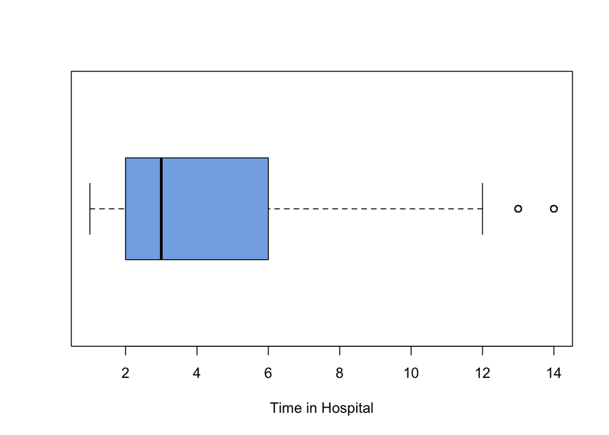

```r
boxplot(db.init$time_in_hospital, horizontal = T, col = '#83afe6', xlab = 'Time in Hospital') # Visible outliers above upper fence
```

```r
fences(db.init$time_in_hospital) # Lower fence is -4 (below the min), and upper fence is 12
```

```
## [1] -4 12
```

```r
length(subset(db.init$time_in_hospital, db.init$time_in_hospital > 12)) # 1403 records have a length of stay higher than the upper fence
```

```
## [1] 1403
```

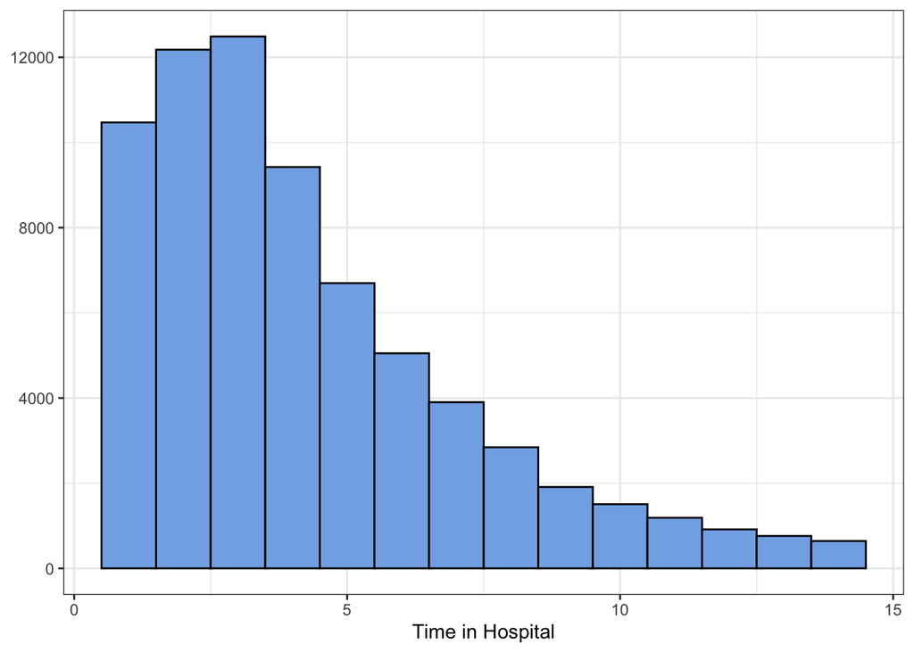

```r
hist.time_in_hospital <- ggplot(db.init, aes(time_in_hospital)) + geom_histogram(binwidth = 1, color='black', fill = '#83afe6') + theme_bw() + labs(x = 'Time in Hospital', y = 'Count') + theme(axis.title.y = element_blank())
hist.time_in_hospital # Distribution is visibly skewed to the right
```

**Number of Lab Procedures**

```r
summary(db.init$num_lab_procedures) # Ranges from 1-132, with a median of 44, mean of 42.88
```

```
##    Min. 1st Qu.  Median    Mean 3rd Qu.    Max.
##    1.00   31.00   44.00   42.88   57.00  132.00
```

```r
sd(db.init$num_lab_procedures) # Standard deviation of 19.895
```

```
## [1] 19.89453
```

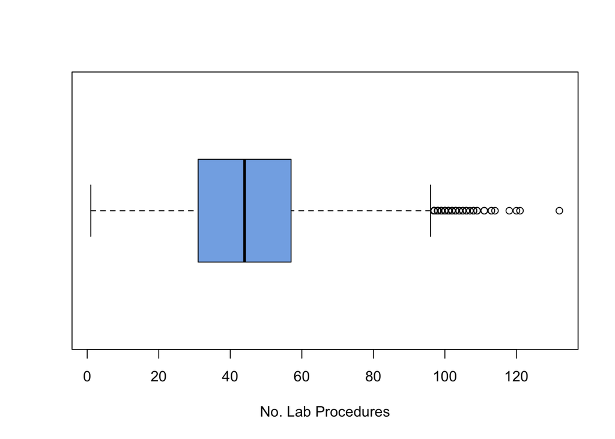

```r
boxplot(db.init$num_lab_procedures, horizontal = T, col = '#83afe6', xlab = 'No. Lab Procedures') # Visible outliers above upper fence
```

```r
fences(db.init$num_lab_procedures) # Lower fence is -8 (below the min), and upper fence is 96
```

```
## [1] -8 96
```

```r
length(subset(db.init$num_lab_procedures, db.init$num_lab_procedures > 96)) # 98 records have a number of lab procedures higher than the upper fence
```

```
## [1] 98
```

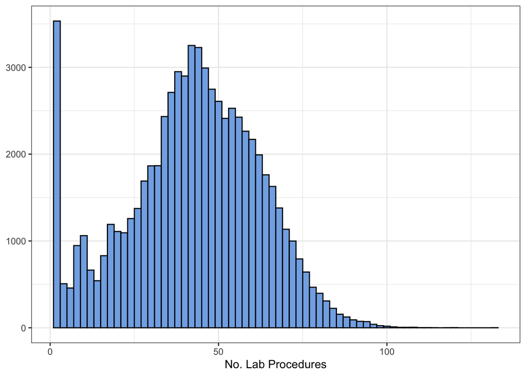

```r
hist.num_lab_procedures <- ggplot(db.init, aes(num_lab_procedures)) + geom_histogram(binwidth = 2, color='black', fill = '#83afe6') + theme_bw() + labs(x = 'No. Lab Procedures', y = 'Count') + theme(axis.title.y = element_blank())
hist.num_lab_procedures # Distribution is unimodal except for large number of values at 1, with outliers visible to the right
```

```r
length(subset(db.init$num_lab_procedures, db.init$num_lab_procedures == 1)) # Of note, 2254 patients had only one lab procedure done
```

```
## [1] 2254
```

**Number of Procedures**

```r
summary(db.init$num_procedures) # Ranges from 0-6, with a median of 1, mean of 1.426
```

```
##    Min. 1st Qu.  Median    Mean 3rd Qu.    Max.
##   0.000   0.000   1.000   1.426   2.000   6.000
```

```r
sd(db.init$num_procedures) # Standard deviation of 1.757
```

```
## [1] 1.757131
```

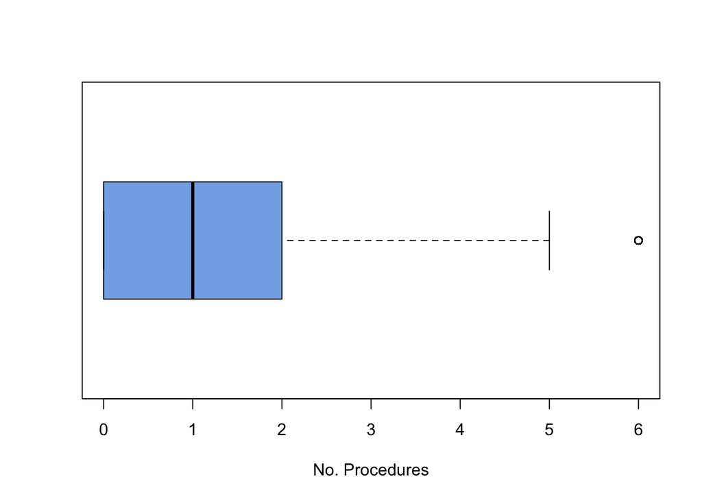

```r
boxplot(db.init$num_procedures, horizontal = T, col = '#83afe6', xlab = 'No. Procedures') # Visible outlier(s) above upper fence
```

```r
fences(db.init$num_procedures) # Lower fence is -3 (below the min), and upper fence is 5
```

```
## [1] -3  5
```

```r
length(subset(db.init$num_procedures, db.init$num_procedures > 5)) # 3845 records have a number of lab procedures higher than the upper fence. However, the only value above the upper fence is 6, so these are all patients who had 6 lab procedures done
```

```
## [1] 3845
```

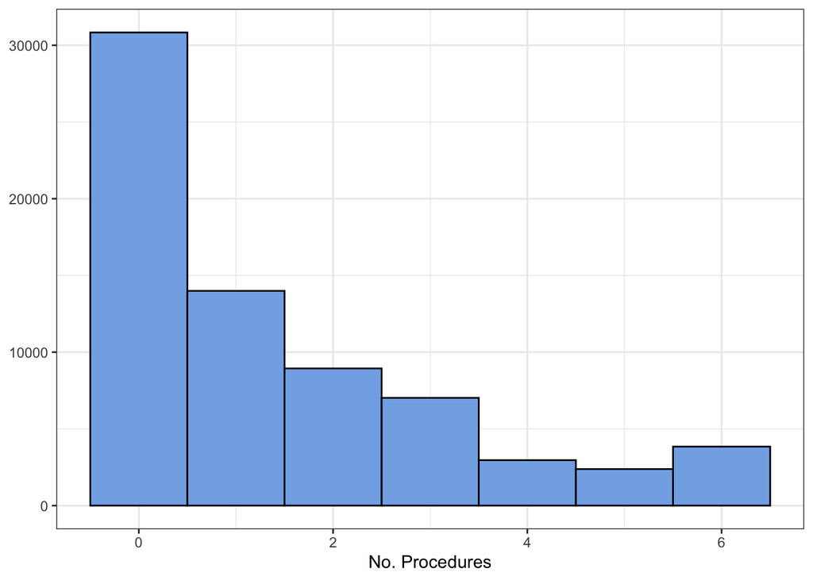

```r
hist.num_procedures <- ggplot(db.init, aes(num_procedures)) + geom_histogram(binwidth = 1, color='black', fill = '#83afe6') + theme_bw() + labs(x = 'No. Procedures', y = 'Count') + theme(axis.title.y = element_blank())
hist.num_procedures # Distribution is skewed right
```

**Number of Medications**

```r
summary(db.init$num_medications) # Ranges from 1-81, with a median of 14, mean of 15.67
```

```
##    Min. 1st Qu.  Median    Mean 3rd Qu.    Max.
##    1.00   10.00   14.00   15.67   20.00   81.00
```

```r
sd(db.init$num_medications) # Standard deviation of 8.287
```

```
## [1] 8.287246
```

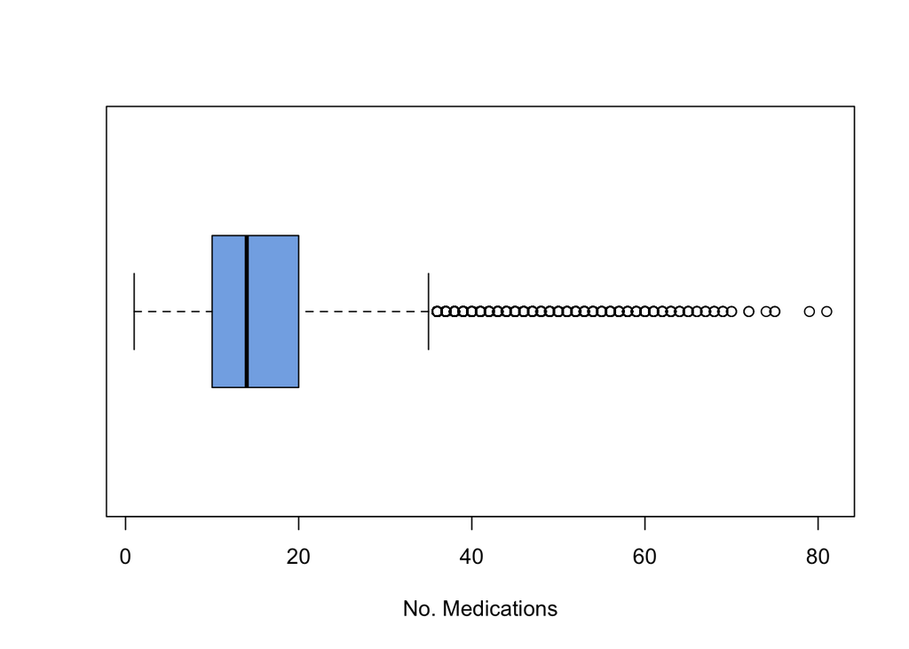

```r
boxplot(db.init$num_medications, horizontal = T, col = '#83afe6', xlab = 'No. Medications') # Many visible outliers above upper fence
```

```r
fences(db.init$num_medications) # Lower fence is -5 (below the min), and upper fence is 35
```

```
## [1] -5 35
```

```r
length(subset(db.init$num_medications, db.init$num_medications > 35)) # 1867 records have a number of medications higher than the upper fence
```

```
## [1] 1867
```

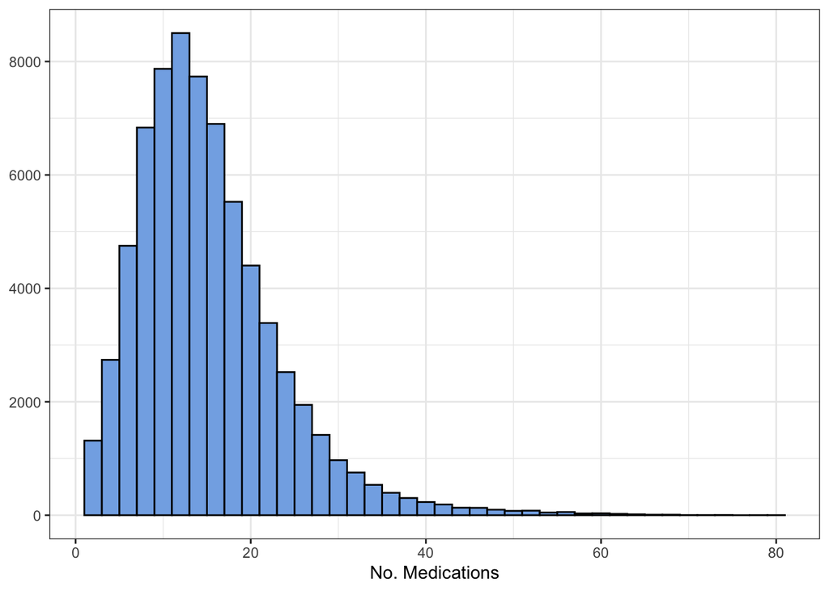

```r
hist.num_medications <- ggplot(db.init, aes(num_medications)) + geom_histogram(binwidth = 2, color='black', fill = '#83afe6') + theme_bw() + labs(x = 'No. Medications', y = 'Count') + theme(axis.title.y = element_blank())
hist.num_medications # Distribution is unimodal and skewed slightly right
```

**Number of Outpatient Visits**

```r
summary(db.init$number_outpatient) # Ranges from 0-42, with a median of 0, mean of 0.2795
```

```
##    Min. 1st Qu.  Median    Mean 3rd Qu.    Max.
##  0.0000  0.0000  0.0000  0.2795  0.0000 42.0000
```

```r
sd(db.init$number_outpatient) # Standard deviation of 1.064
```

```
## [1] 1.064035
```

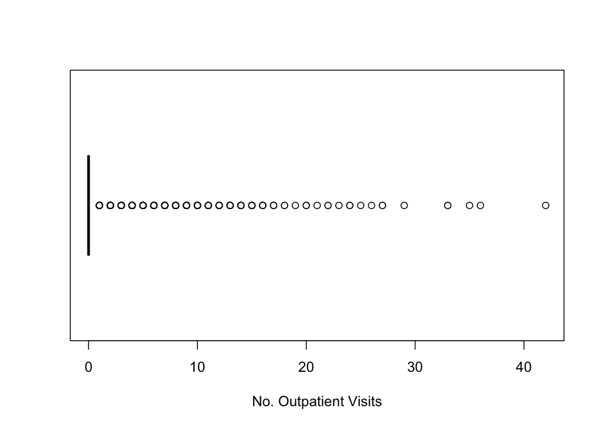

```r
boxplot(db.init$number_outpatient, horizontal = T, col = '#83afe6', xlab = 'No. Outpatient Visits') # Many visible outliers above upper fence
```

```r
fences(db.init$number_outpatient) # Lower fence is 0, and upper fence is 0
```

```
## [1] 0 0
```

```r
length(subset(db.init$number_outpatient, db.init$number_outpatient != 0)) # 9119 records have a number of outpatient visits higher than the upper fence. I.e., had more than 0 outpatient visits in the last year
```

```
## [1] 9119
```

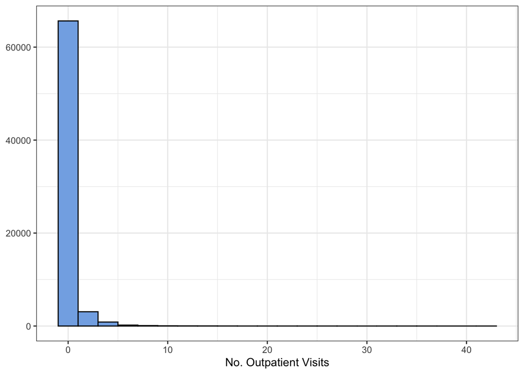

```r
hist.number_outpatient <- ggplot(db.init, aes(number_outpatient)) + geom_histogram(binwidth = 2, color='black', fill = '#83afe6') + theme_bw() + labs(x = 'No. Outpatient Visits', y = 'Count') + theme(axis.title.y = element_blank())
hist.number_outpatient # Most cases are zero
```

```r
table(db.init$number_outpatient) # The vast majority of cases (60854) are zero, and the rest of the data is skewed right
```

```
##
##     0     1     2     3     4     5     6     7     8     9    10    11    12
## 60854  4779  1981  1096   574   278   122    72    56    36    28    18    13
##    13    14    15    16    17    18    19    20    21    22    23    24    25
##    13    10    10     7     4     2     1     3     1     2     1     2     1
##    26    27    29    33    35    36    42
##     1     2     1     2     1     1     1
```

**Number of Emergency Visits**

```r
summary(db.init$number_emergency) # Ranges from 0-42, with a median of 0, mean of 0.1039
```

```
##    Min. 1st Qu.  Median    Mean 3rd Qu.    Max.
##  0.0000  0.0000  0.0000  0.1039  0.0000 42.0000
```

```r
sd(db.init$number_emergency) # Standard deviation of 0.512
```

```
## [1] 0.5118705
```

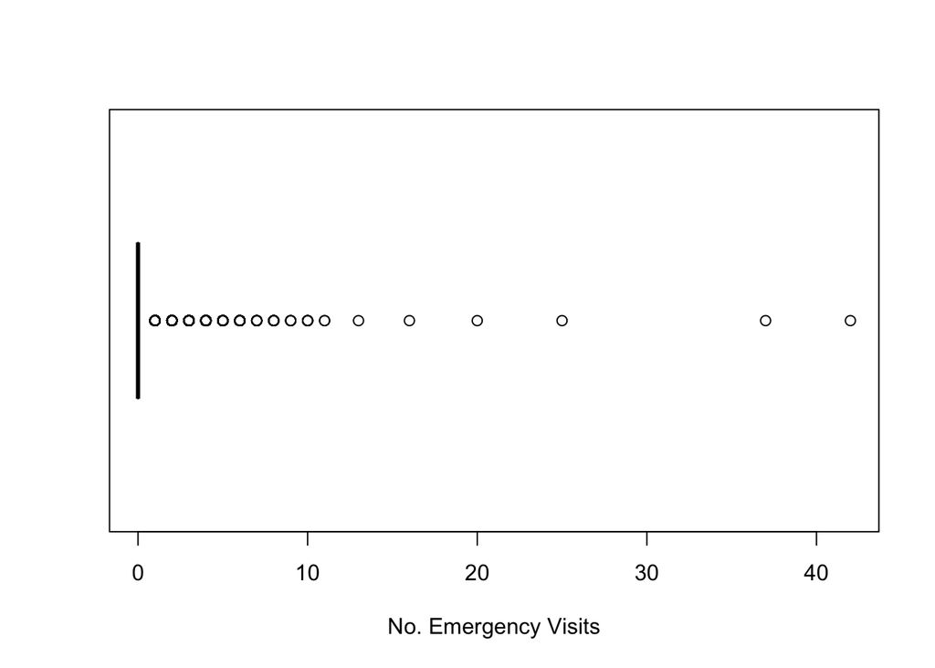

```r
boxplot(db.init$number_emergency, horizontal = T, col = '#83afe6', xlab = 'No. Emergency Visits') # Many visible outliers above upper fence
```

```r
fences(db.init$number_emergency) # Lower fence is 0, and upper fence is 0
```

```
## [1] 0 0
```

```r
length(subset(db.init$number_emergency, db.init$number_emergency != 0)) # 5100 records have a number of emergency visits higher than the upper fence. I.e., had more than 0 emergency visits in the last year
```

```
## [1] 5100
```

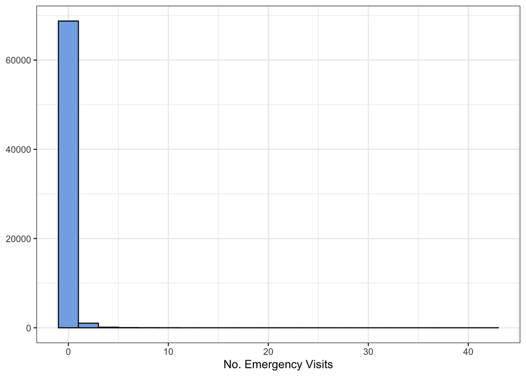

```r
hist.number_emergency <- ggplot(db.init, aes(number_emergency)) + geom_histogram(binwidth = 2, color='black', fill = '#83afe6') + theme_bw() + labs(x = 'No. Emergency Visits', y = 'Count') + theme(axis.title.y = element_blank())
hist.number_emergency # Most cases are zero
```

```r
table(db.init$number_emergency) # The vast majority of cases (64873) are zero, and the rest of the data is skewed right
```

```
##
##     0     1     2     3     4     5     6     7     8     9    10    11    13
## 64873  3882   789   242    95    32    26     8     9     4     5     2     1
##    16    20    25    37    42
##     1     1     1     1     1
```

**Number of Inpatient Visits**

```r
summary(db.init$number_inpatient) # Ranges from 0-12, with a median of 0, mean of 0.1763
```

```
##    Min. 1st Qu.  Median    Mean 3rd Qu.    Max.
##  0.0000  0.0000  0.0000  0.1763  0.0000 12.0000
```

```r
sd(db.init$number_inpatient) # Standard deviation of 0.602
```

```
## [1] 0.6016572
```

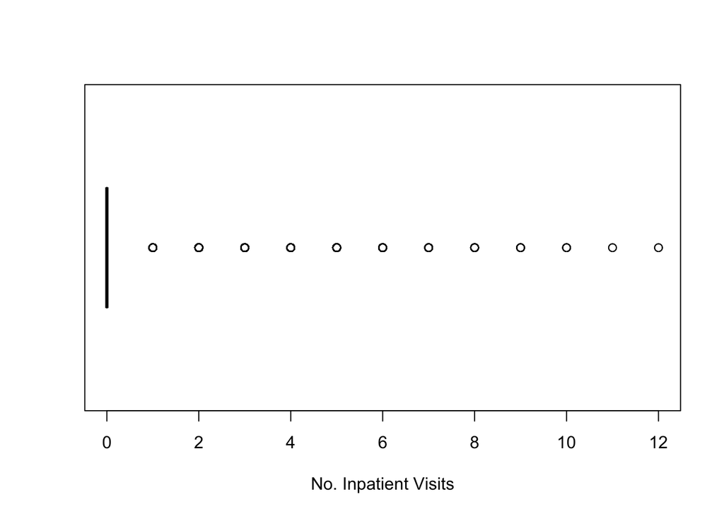

```r
boxplot(db.init$number_inpatient, horizontal = T, col = '#83afe6', xlab = 'No. Inpatient Visits') # Visible outliers above upper fence
```

```r
fences(db.init$number_inpatient) # Lower fence is 0, and upper fence is 0
```

```
## [1] 0 0
```

```r
length(subset(db.init$number_inpatient, db.init$number_inpatient != 0)) # 8191 records have a number of inpatient visits higher than the upper fence. I.e., had more than 0 inpatient visits in the last year
```

```
## [1] 8191
```

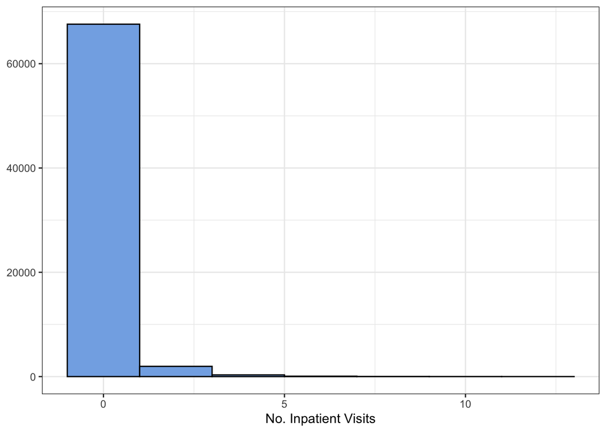

```r
hist.number_inpatient <- ggplot(db.init, aes(number_inpatient)) + geom_histogram(binwidth = 2, color='black', fill = '#83afe6') + theme_bw() + labs(x = 'No. Inpatient Visits') + theme(axis.title.y = element_blank()) + theme(axis.title.y = element_blank())
hist.number_inpatient # Most casesa are zero
```

```r
table(db.init$number_inpatient) # The vast majority of cases (61782) are zero, and the rest of the data is skewed right
```

```
##
##     0     1     2     3     4     5     6     7     8     9    10    11    12
## 61782  5794  1501   463   228   102    55    19    13     7     5     2     2
```

**Number of Diagnoses**

```r
summary(db.init$number_diagnoses) # Ranges from 1-16, with a median of 8, mean of 7.224
```

```
##    Min. 1st Qu.  Median    Mean 3rd Qu.    Max.
##   1.000   6.000   8.000   7.224   9.000  16.000
```

```r
sd(db.init$number_diagnoses) # Standard deviation of 2.001
```

```
## [1] 2.001354
```

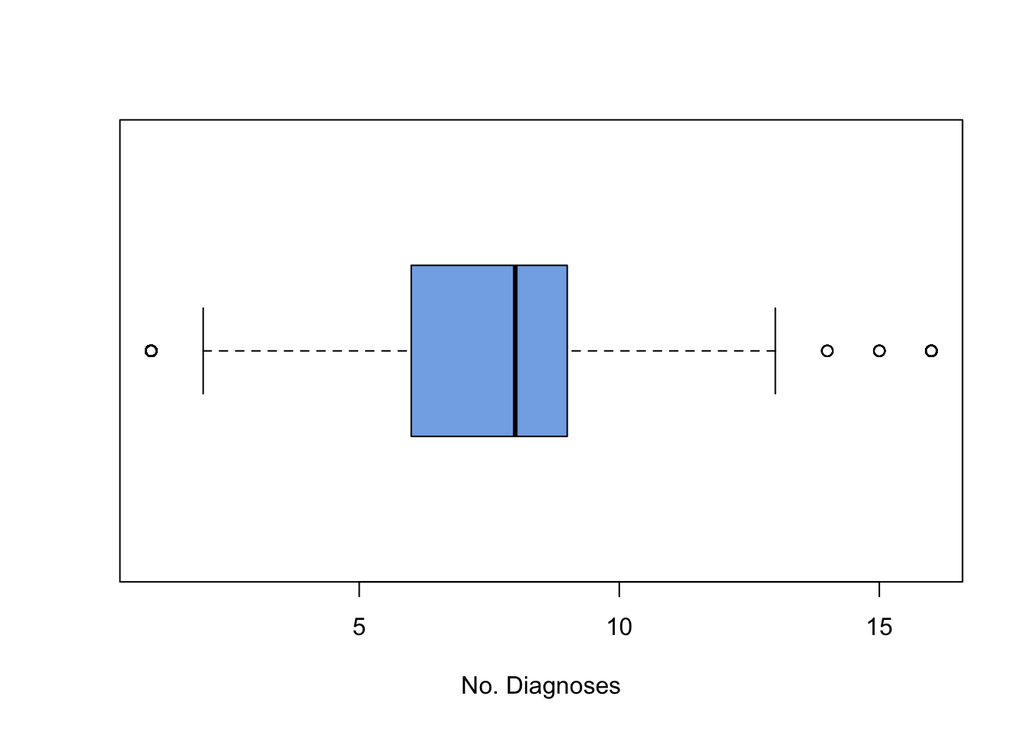

```r
boxplot(db.init$number_diagnoses, horizontal = T, col = '#83afe6', xlab = 'No. Diagnoses') # Visible outliers above upper fence and below lower fence
```

```r
fences(db.init$number_diagnoses) # Lower fence is 1.5, and upper fence is 13.5
```

```
## [1]  1.5 13.5
```

```r
length(subset(db.init$number_diagnoses, db.init$number_diagnoses < 1.5)) # 193 cases are below the lower fence. I.e., 193 people had 1 diagnosis, as 1 is the min
```

```
## [1] 193
```

```r
length(subset(db.init$number_diagnoses, db.init$number_diagnoses > 13.5)) # 42 records have a number of diagnoses higher than the upper fence
```

```
## [1] 42
```

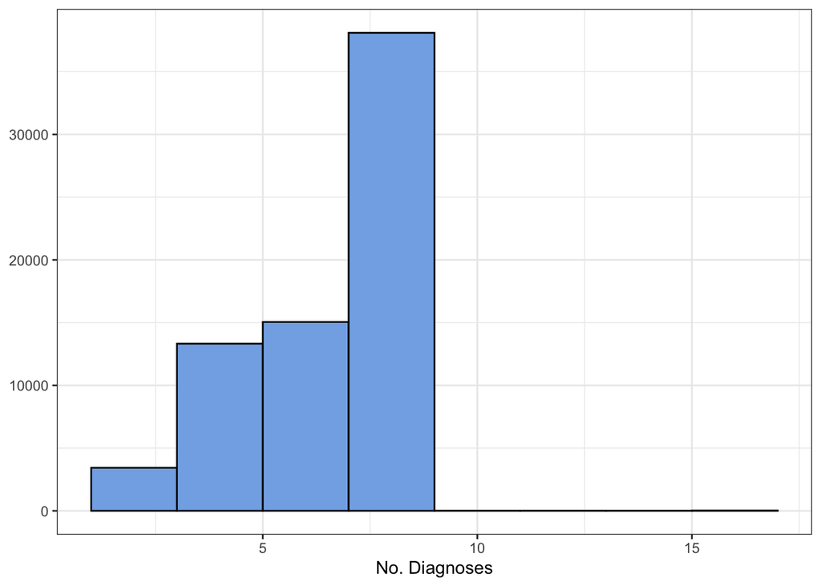

```r
hist.number_diagnoses <- ggplot(db.init, aes(number_diagnoses)) + geom_histogram(binwidth = 2, color='black', fill = '#83afe6') + theme_bw() + labs(x = 'No. Diagnoses', y = 'Count') + theme(axis.title.y = element_blank())
hist.number_diagnoses # Skewed left from 1-9
```

```r
table(db.init$number_diagnoses) # From diagnoses 1-9, the data is skewed left. There are very few cases 10 and above. Since there is no biological reason for this, this finding suggests to me that there is some reason coding for more than 9 diagnoses may be difficult in the system, so many practitioners don't bother for an inpatient visit
```

```
##
##     1     2     3     4     5     6     7     8     9    10    11    12    13
##   193   881  2357  4442  8881  7566  7485  7391 30704     9     6     6    10
##    14    15    16
##     5     7    30
```

```r
length(subset(db.init$number_diagnoses, db.init$number_diagnoses > 9)) # 73 cases have more than 9 diagnoses
```

```
## [1] 73
```

The following are grouped visualizations of the numeric attributes above, specifically the histograms and boxplots.

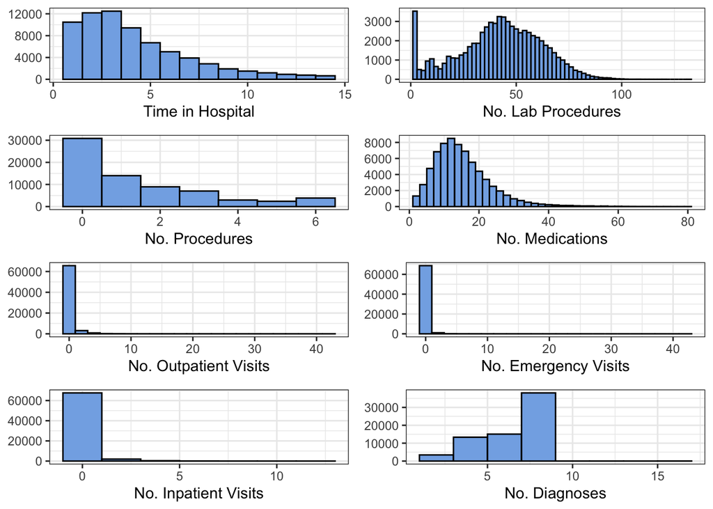

```r
grid.arrange(hist.time_in_hospital, hist.num_lab_procedures, hist.num_procedures, hist.num_medications, hist.number_outpatient, hist.number_emergency, hist.number_inpatient, hist.number_diagnoses, nrow = 4) # Histograms together
```

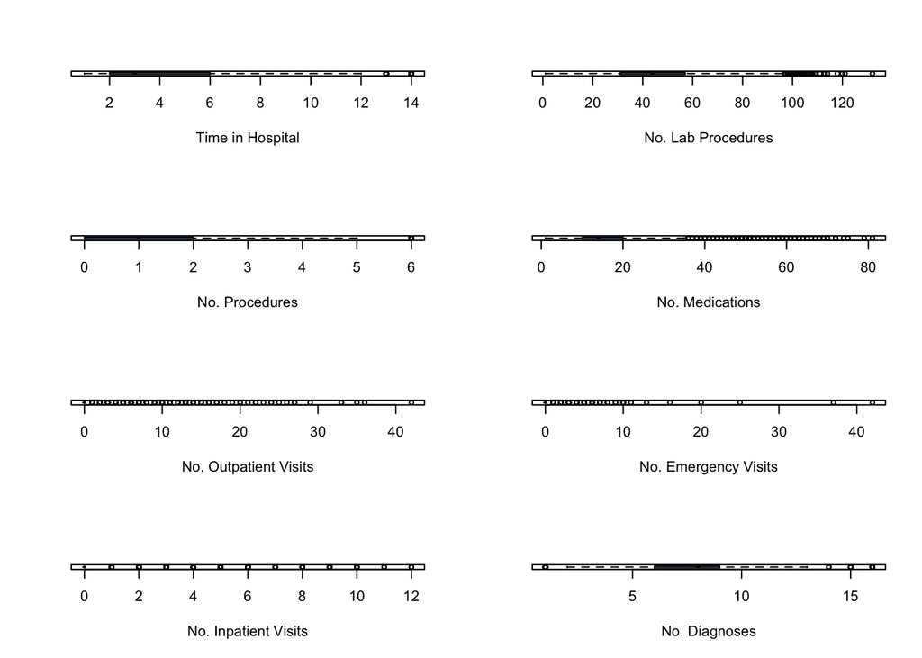

```r
par(mfrow=c(4,2)) # Boxplots together
boxplot(db.init$time_in_hospital, xlab = 'Time in Hospital', las=1, horizontal = T, col = '#83afe6')
boxplot(db.init$num_lab_procedures, xlab = 'No. Lab Procedures', las=1, horizontal = T, col = '#83afe6')
boxplot(db.init$num_procedures, xlab = 'No. Procedures', las=1, horizontal = T, col = '#83afe6')
boxplot(db.init$num_medications, xlab = 'No. Medications', las=1, horizontal = T, col = '#83afe6')
boxplot(db.init$number_outpatient, xlab = 'No. Outpatient Visits', las=1, horizontal = T, col = '#83afe6')
boxplot(db.init$number_emergency, xlab = 'No. Emergency Visits', las=1, horizontal = T, col = '#83afe6')
boxplot(db.init$number_inpatient, xlab = 'No. Inpatient Visits', las=1, horizontal = T, col = '#83afe6')
boxplot(db.init$number_diagnoses, xlab = 'No. Diagnoses', las=1, horizontal = T, col = '#83afe6')
```

Now we’ll identify the overall number of outliers for the numeric attributes.

```r
nrow(subset(db.init, db.init$time_in_hospital > 12 | db.init$num_lab_procedures > 96 | db.init$num_procedures > 5 | db.init$num_medications > 35 | db.init$number_outpatient != 0 | db.init$number_emergency != 0 | db.init$number_inpatient != 0 | db.init$number_diagnoses < 1.5 | db.init$number_diagnoses > 13.5)) # There are 23159 rows in which at least one outlier is present
```

```
## [1] 23159
```

```r
23159/69973 # 33.1% of records in the dataset contain one or more outliers; these will be kept as they may all represent real cases based on their values. Additionally, neural networks are somewhat robust to outliers
```

```
## [1] 0.3309705
```

We will transfer the numeric attributes kept to a new clean dataframe (db.expl) for further exploratory analysis.

```r
db.expl <- db.init[,c(10, 13:18, 22)]
```